# Across the Years 2024-2025 6-Day Race Recap

Recapping my first ultra endurance event

life

running

Published

January 7, 2025

I’m not one to half-ass things, and that couldn’t be more true than my decision to run ATY’s 6-day race as my first-ever ultra-distance event–a decision that left other runners in varying degrees of shock when I would mention it in conversation. I tried to make it clear to these folks that I wasn’t coming in to the event blind. In fact, I spent nearly the entirety of 2024 training specifically for ATY and am hoping to do some post-mortem blogs about my training once I get a little separation from everything. But before I get ahead of myself (and while memories are still fresh), let’s talk about my experience at the event.

> Might screw around and micro blog my first time at a 6 day run instead of trying to keep a notebook 🏃  
> [[ image or embed]](https://bsky.app/profile/did:plc:62vzwbgedkk4sx4fox34bwz2/post/3leeucnv47s2i?ref_src=embed)

> — Matt Sams ([@mattsams.com](https://bsky.app/profile/did:plc:62vzwbgedkk4sx4fox34bwz2?ref_src=embed)) [December 28, 2024 at 8:52 AM](https://bsky.app/profile/did:plc:62vzwbgedkk4sx4fox34bwz2/post/3leeucnv47s2i?ref_src=embed)

# Day 1

The 6-day race began at 9 AM on Saturday, December 28th. I got to the venue around 7:30 to move my gear to a rented tent and settle in before kickoff. I was feeling really good–my year-high 118-mile (190 km) week was firmly behind me, and my few lingering overuse issues had improved to dull aches at worst. I was nervous, but confident, and had set my distance goal to 250 miles (~ 400 km; I’ll try to convert these). I figured that if I had run nearly 125 miles in training, I could run-walk and walk at least double that, right?

Speaking of run-walk, I don’t yog (or jog with a soft ‘j’), so I settled on run-walking the event. In retrospect, I wish I had practiced the run-walking a bit more.

At any rate, I had practiced 4 or 5 different run-walk cadences and had settled on alternating between a 5 km walk and 4 rounds of 2 km run - 0.5 km walk (shortened to 2k-0.5k [run-walk], FYI). To save you the math, each cycle worked out to 15 km (~ 9.3 mi), with 8 km (5 mi) of that being running, and would take a little over 2 hours to complete with my target run-walk paces. Given my distance goal, I was looking at 4 run-walk cycles plus a little more walking each day to hit my daily target (41.7 mi; 67 km).

At the gun, I took off with a blazingly fast walking pace, and that’s only a little bit of a lie. Early on that first day, there were *a ton* of fast walkers on the course, so I settled in behind some folks who were cranking out 15:40 miles. I’m not a particularly fast walker (being a “plodder” extends to multiple facets in my life), so following them kept me moving at a good clip for that first 5 km.

From there, my run-walk execution was about as spot-on as it could be. I finished my first run-walk cycle in 1:54:00, about 9 minutes faster than what I had practiced in training. Funnily enough, all that time saved came from my faster-than-normal walking speed. From there, to bastardize some Smash Mouth, the run-walk miles kept comin’ and they didn’t stop comin’, so I hit 37 miles (60 km) in 7:39:27. That meant I was a little over 30 minutes ahead of schedule, and I felt *great*.

Since I was feeling good, I decided to tack on an additional run-walk cycle after I hit my target for the day. I tried to stay cognizant of the fact that this was a 6-day race, though, so I dropped my run-walk cadence from 2k-0.5k to 1k-0.5k to give myself more frequent breaks. With the extra run-walk cycle, I finished 36 laps (50.7 mi; 81.5 km) in 11:22:56.

The crowd had thinned considerably since the marathon, 6-hour, and 12-hour runners were already off the course, so I didn’t have many options for following faster walkers. On top of that, I was pretty tired after that last round of run-walk, so my walking pace dropped by about a minute compared to where it had been earlier in the day. That meant my gait changed, and with that changed gait came the first twinges of problems I would carry the rest of the event.

I don’t know what mile it actually happened, but a spot just below my knee (lateral gastroc / biceps femoris insertion / peroneal origin?) started to flair up. This wasn’t the first time I’d experienced this pain–it had cropped up a few times during run-walk practice–but it grew from twinge to straight-up pain, which *was* new. I tried to adjust my walking gait to compensate, but nothing seemed to help, so I hobbled to my tent after lap 40 and called it a night.

Despite the lackluster end to the day, my performance left me hopeful that I’d be able to push for 300+ miles instead of my original goal of 250. I even briefly entertained the idea of 350 miles (563 km), but the next few days would crush that dream.

- Daily Distance: 40 laps (56.3 mi; 90.6 km)
- Time: 13:13:15
- Pace: 14:05/mi; 08:45/km

# Day 2

Following a freezing night fraught with tossing and turning, I was back on the track by about 6:20 AM. My knee pain was all but forgotten, but something else had taken its place: a swollen ankle. I have to assume the knee the night before, coupled with general foot and ankle swelling, had put lace pressure on my dorsal (top of) foot and extensor tendons, so they were *angry*. And by angry, I mean that shit hurt. Every step was painful no matter what I did, so I set off at a much slower walking pace than Day 1 to see if moving for a while would sort things out.

Spoiler, it did not. The pain remained, and all I had to show for it was a dreadfully slow pace compared to Day 1. It took me 3 hours to cover the first 10 miles (16 km). My foot and ankle weren’t doing me any favors–in fact, they were causing irritation in my knee and opposite heel–so I went back to run-walking. For reasons that only made sense in the moment, I changed from my original 2k-0.5k to 0.5k-0.5k repeats. I assume it was for more frequent rest breaks, but I couldn’t tell you for sure.

During that break, I realized I should have invested in a zero gravity chair because staying comfortable while elevating my feet in the tent was a struggle. I had rented a cot along with the tent, so I tried laying on the floor with my feet propped on the cot. Unfortunately, the cot’s metal edge dug into *something* no matter how I laid and no matter what I used as a buffer between the cot and my poor legs, so I was more irritated than rested by the time I continued.

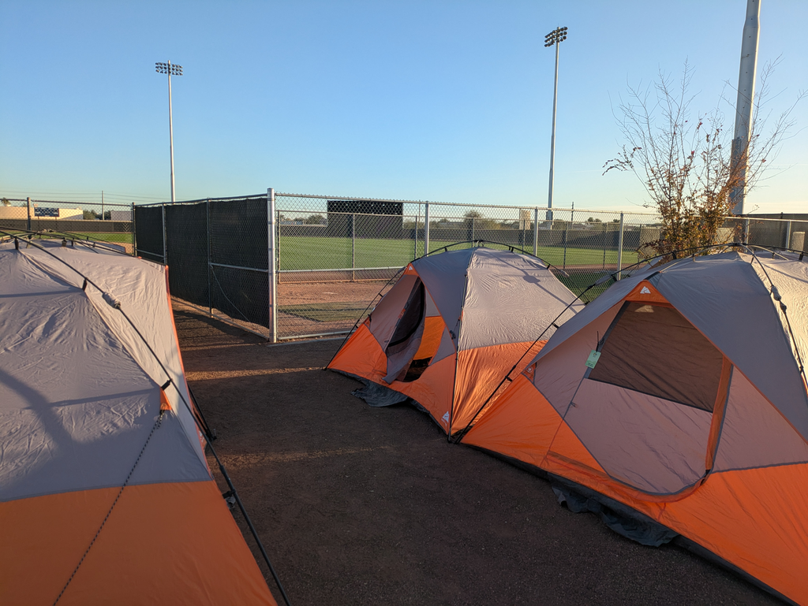

I followed my lie-down with 3 more walking laps before resuming run-walking. I stuck to the 0.5k-0.5k I had been doing earlier, but I only managed 10 reps before taking another break to lie down in the tent. By this point, my feet were really hurting. The aforementioned dorsal foot and extensor tendon pain and swelling were still there, but we could also add great toe pain and right heel pain to the mix. It finally dawned on me that I should loosen my left shoe, so I loosened that bad boy then went for a few more run-walk reps.

My last run-walk of the day left me at 29 laps (41.2 mi; 66.3 km) in 11:30:37. Day 1 hit 29 laps in 8:55:49, which is what you might call a concerning comparison. I still had my hair-brained idea to hit 350 miles by the end, so I decided to keep walking until I hit 40 laps (56.3 mi; 90.6 km). In retrospect, I should have done more run-walking, but the new pains were leaving me at a loss for their cause (*time on feet, Matthew*). I pressed on for 8 more walking laps.

- Daily Distance: 37 laps (52.2 mi; 84 km)
- Time: 15:53:07
- Pace: 18:15/mi; 11:21/km
- Cumulative Distance: 77 laps (108.5 mi; 174.6 km)

# Day 3

I think Night 2 was colder than Night 1, despite what Weather Underground says. Regardless, I slept marginally better and set out at 7:30 AM.

Compared to Day 2, I did *even more walking* to start the day. I hit 10 laps (14.2 mi; 22.8 km) after 4 hours then did some weird run-walking that Imma be real honest about here: I have no clue what I was doing on Day 3. Literally none. Zero. Zilch. Nada. I’m looking at my velocity trace from my downloaded data, and I *cannot* figure out what I was doing. Maybe alternating 250 meters of running with 250 meters of walking? No idea.

Regardless, I did whatever I was doing for an hour and a half, laid down in the tent for a bit, then did another half hour of ambiguous run-walking. After 10 hours on the course, I had completed 23 laps (32.7 mi; 52.5 km)–9 fewer than Day 1’s 10 hour mark.

By this point, I was getting frustrated. I think I recognized that overindexing on walking was contributing to my foot and knee pain, but I was afraid to push the pace for fear of exacerbating the foot issues. I knew I needed a pick-me-up, so I decided I would go home to sleep instead of spending another miserable night in the tent. I actually don’t know how common it is for races to allow this, but I’m glad ATY is so permissive.

Just making the decision to go home gave me something to look forward to, so I got back on the course and powered through another 10 miles of ambiguous run-walking. I crossed the start/finish with my final run-walk rep of the day, having completed 29 laps (41.2 mi; 66.3 km) in just over 12 hours. I wanted to walk until I hit 37 laps to keep building a buffer for the final day, but my resolve was spent by the time I hit 35. Given my house is also 30 minutes from the course, I didn’t want to stay out super late and limit my sleep at home.

The drive home was uneventful, but lemme tell you how much getting out of the car sucked. I love my little Honda, but you won’t see it next to “comfortable seating” in the dictionary. I could feel the aches and pains building before I got out of the car, but standing up and walking inside may have been the most difficult thing I did on Day 3. Thanks to my tile floors, my feet were screaming with every step, but nothing was going to keep me from a hot shower and a warm bed. Shower completed, I propped my legs up with some pillows and trailed off until 6 AM.

- Daily Distance: 35 laps (49.3 mi; 79.3 km)
- Time: 14:39:33
- Pace: 17:50/mi; 11:05/km
- Cumulative Distance: 112 laps (157.8 mi; 253.9 km)

# Day 4

[figure not shown]

Speaking of laps, it was around this point that my mind stopped thinking about miles and focused exclusively on the lap count. Something about the number being under 100 made my lizard brain happy.

Despite recognizing I needed less time on feet to better manage my knee and feet, I started the day with 15 miles (24 km) of walking. I think I was hoping things would loosen up and/or stop hurting with some extended walking, but I know I was lying to myself. I was already 5 hours in, and I had produced some of my slowest walking laps of the entire event.

Even worse, an attempted shoe swap to reduce the stress on my feet and ankles just made matters worse. The shoes were identical make and model, but they didn’t have the same hyper-specific lace adjustments of my first pair. In less than half an hour, I swapped back to the original pair, but the damage was already done: being really sciency with this, the different lace pressure annihilated the tendons on the dorsal (top) part of my foot. *Everything* swelled. In switching back to my previous shoes, I had to let out the laces as much as possible to A) fit my feet in the shoes and B) reduce the pain from a 7/10 -> 5/10.

Once I got back on the course, I wanted to get the day over as quickly as possible. So, after one final walking lap to adjust my laces, I re-started run-walking. I figured that, even if running would irritate my everything more than walking, at least I’d be off the course sooner. I started with 9 rounds of 0.5k-0.5k before running 4 rounds of 1k-0.5k.

The wheels didn’t fall off, but the pain in the soles of my feet grew steadily throughout the intervals. Especially when it came to the right foot, loosening the laces had created more heel bounce in the shoe. I made the tough decision to re-tighten the top laces to control the heel and hoped the lace pressure wouldn’t be too much.

After 3 more walking laps, I performed another 7 reps of 1k-0.5k. Actually, the first cycle was 1.5k-0.5k because I thought I wanted to do that like an insane person, but I immediately stopped. After my last run-walk rep, I was 27 laps (38 mi; 61 km) into the day, so I decided I would take one more lie-down before run-walking my way to victory.

It was on lap 140, off the back of my last lie-down, that disaster struck.

I planned on walking a lap to shake off the rust before continuing with run-walk reps. But, as I hit the half-lap timing gate, *I didn’t hear a beep*. My head snapped down, and my eyes confirmed what I feared: I had forgotten the bib in my tent. I was in such an awkward spot in the course, I didn’t know if it would be faster to backtrack or continue around the course. I finally settled on the latter, which was a terrible idea in restrospect. That little maneuver cost me 24 minutes, or the equivalent of a full walking lap.

Walking back to my tent and re-walking the half lap to hit the timing gate was the second lowest moment I had during the race. I was exhausted, I was irritated at forgetting my bib, I was upset with myself for signing up for the race. Y’know, really positive headspace. I wanted to lay down again and call it a day, but my stubbornness wouldn’t allow it.

It took a while to compose myself after the bib snafu; I walked 6 mindless laps before kicking it into gear for a coulple more run-walk reps. Funnily enough, I was so over it that I turned in 2 of my fastest laps of the event–a 16:20 and a 15:34. At any rate, the run-walk took me to lap 147 (207.1 mi; 333.2 km), a gain of 35 laps. That left 66 laps (93.7 mi; 150.8 km) to hit my goal. I didn’t like ending on 66 (don’t ask me why, it just felt, and still feels, bad/wrong/icky), so I walked 2 more laps before calling it a night.

- Daily Distance: 37 laps (52.2 mi; 84 km)
- Time: 15:52:33
- Pace: 18:15/mi; 11:20/km
- Cumulative Distance: 149 laps (209.9 mi; 337.7 km)

# Day 5

As I drifted off the night before, I swore I was going home Night 6 come hell or high water. In my brain, that meant I *must* complete at least 32 laps (45.4 mi; 73.1 km) so I would have fewer than 50 miles (80 km) remaining on Day 6. That number felt important, like I wouldn’t be up to finishing more than 50 miles on the final day. Deep down, I knew that was bullshit and that I would drag myself across broken glass to hit 300 miles, but think of it like the college undergrads who “work best under pressure.” Brains are funny things.

Anyway, I wasn’t feeling particularly great the morning of Day 5. The pain and swelling in my feet might as well have been permanent fixtures in my life, but I had laps to complete. I was reminded of a phrase I jokingly use with friends and coworkers when discussing things we don’t want to do: suck it up, buttercup. And so I did.

Day 5 is the only day I didn’t run. I had dealt with a few twinges in my hip flexors on Day 4, and I wanted to give my battered extensor tendons some time to calm down from the shoe replacement disaster. I knew I couldn’t walk *ad infinitum* without irritating my feet and knee, so I considered my options as I finished my first lap of the day. It was obvious that 1) continuously walking wasn’t something I could do this deep into the race and 2) my feet and knee tended to feel better after a lie-down in the tent. Taken together, I decided to walk as fast as I could with rest breaks every 4-8 laps.

That idea to rest every 4-8 laps turned into a block of 7 laps, 4 blocks of 5 laps, and one block of 4 laps. Math is hard. So is walking for 16 hours. I honestly have very little to say about the process of Day 5 because it was largely mindless as I pounded the pavement.

One bright spot in the proverbial darkness was that walking all my laps gave me more time to chat with other race goers. I met quite a few folks I had been walking and running with for the last 5 days and also chatted with runners in the shorter races (it’s funny when a 72-hour race is a short race). We talked training histories, work histories, life histories, all the histories. We also chatted about the absolute insanity that was the Last Person Standing–for posterity’s sake, both the winner and runner-up ran 109 laps (153.8 mi; 247.5 km), but the winner finished his lap 5:28 under the cutoff while the runner-up missed the cutoff by 43 seconds. The format for the Last Person Standing? Start and finish a lap every 20 minutes or you’re out, so those poor souls had been running for *36 hours*. In an event full of sickos, they truly were the sickest.

Despite the entertainment, the positive interactions with an abundance of kind people, and the extra rest, the end of Day 5 was the darkest part of the event for me. While walking had given my hips and ankles a break, the knee and feet weren’t so lucky. In fact, I had developed a pretty severe hitch in my gait by the time I finished my final rest of the day. I needed 5 laps to stay on target, but I had slowed to a crawl by lap 177 (249.3 mi; 401.1 km); Strava shows I was logging 11:50/km splits, which is a full 2 minutes slower than my Day 1 walking pace and 1.5 minutes slower than my average throughout the afternoon.

I felt defeated as I zombie shuffled my way through 4 laps. I think if walking hadn’t hurt as much as it did, I might’ve called it quits and gone home. Ironically, the thought of the half-mile walk to my car, the 30 minute drive home, and the excruciating pain of walking on my tile floor is what kept me in the tent that night. That and the registration fee 🙃.

After sitting in the tent with my head in my hands for 15 minutes, I remember sighing and saying, “You’re getting cold. Go to bed. Finish tomorrow. Never do this again.” To bed I went.

- Daily Distance: 31 laps (43.7 mi; 70.3 km)
- Time: 15:57:47
- Pace: 21:55/mi; 13:37/km
- Cumulative Distance: 180 laps (253.6 mi; 408 km)

# Day 6

(Pre) dawn of the final day. I wanted to be done, so my intention was to walk for the first few hours to loosen up then run-walk to the end. If I broke a metatarsal? Run-walk. If I strained a hip flexor? Run-walk. No. Matter. What. Run-walk. Gone were the lie-downs from Day 5; we were getting this over with.

Despite saying that, I may or may not have walked the first 10 laps (14.2 mi; 22.8 km). Despite my eagerness to be done, I am Southern first and foremost, so I literally cannot interrupt a nice conversation to say, “Hey, I gotta run for a while. I’ll talk to you when I finish.” And the universe knows that, so I spoke with so many lovely people in the 4.5 hours I walked and talked. And let’s be real, as much as I wanted to be done, I knew I had 26 hours to complete 46.4 miles (74.7 km). I was close.

How close I was to my goal finally hit me after my first series of run-walk. After turning in 10 reps of 0.5k-0.5k, I glanced at the timing board at the start/finish and realized I had 26.7 miles (43 km) remaining. One marathon and some change.

I started doing the mental math. It was 1:30 PM. If I wanted to destroy myself, I could theoretically be done by 5:30, but running a 4 hour marathon this deep into the event was neither wise nor feasible. Instead, I stuck to Ole Reliable and pounded out more 0.5k-0.5k. I ever so briefly flirted with 2k-0.5k, but it was 77°F (25°C) without a cloud in the sky, so I aborted that idea after a single rep.

After 15 more run-walk reps, I needed 10 laps (14.2 mi; 22.8 km) to reach my goal. I stopped to eat, walked a lap to let it settle, then set out on my final block of run-walk. Or so I thought. My Southernness (and let’s be real, loneliness and misery) got the better of me, so I walked and talked with a few more runners until I was T-5 laps from my goal.

At that point, though, I couldn’t stand it anymore and actually told a very nice individual, “Hey, I need 5 laps to hit my goal. It’s been nice chatting, but I have to go or I may go insane.” They just laughed and waved me on.

Seven more run-walk reps took me to 212 laps (298.6 mi; 480.4 km). I had every intention of turning in a 10:00 lap when I saw another 6-dayer sloooooooooowly taking a lap after grinding through 64.1 miles (103.1 km) in a little over 14.5 hours. Don’t mind him, just turning in an average pace of 13:40/mi (8:30/km) 6 days into this thing.

No matter what my brain was telling me in that moment, walking and talking the final lap was far better than running it by myself. This runner lived in northeast Tennessee and knew all my old haunts, so we talked favorite places to run, places I should visit the next time I was in town, places he should visit the next time he was in AZ, the works. I still turned in a 26:40 lap, so it’s not like we were taking a Sunday stroll.

At any rate, I crossed the start/finish, took a picture at the timing board, and wandered off into the night.

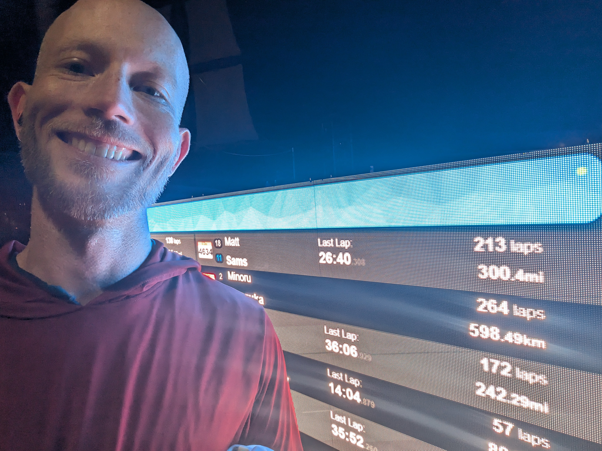

- Daily Distance: 33 laps (46.4 mi; 74.7 km)
- Time: 13:14:41
- Pace: 17:08/mi; 10:39/km
- Cumulative Distance: 213 laps (300 mi; 482.7 km)

…Just kidding.

# Day 6, Part 2

I hit my goal in such a better headspace than at the end of Day 5. Relief, elation, and a healthy dose of comraderie had lifted my spirits to the highest they’d been since Bibgate, so I decied I’d go home, sleep a few hours, then come back for a few more laps on the final morning (ok, and maybe to make sure I finished ahead of my nemesis fellow Tennesseean, but no one needs to know that).

I got home around 9:30 PM. I was covered in dust and hadn’t shaved my head in nearly a week, so I made myself slightly more presentable before collapsing into bed. I had set my alarm for 6 AM, but I was too antsy and was up by 5:15. I took the time to brew a little coffee, then I made my way to the course for my victory laps.

Those laps were some of the best of the race; I needed 3 to pass the other Tennesseean, so I took 2 slow laps with some folks named Zerek and Andreina. Poor Zerek hit his limit for running on concrete and asphalt around 4:30 AM of Night 5, so he and Andreina were taking a few walking laps around the course. I had enjoyed hanging out with them earlier in the week, so I was happy to join them for a while before picking up the pace.

My final lap, I followed behind a parade of celebrating runners. There must have been 15 cowbells ringing the entirety of that last 1.42 miles. I made my final start/finish crossing at 8:51:14 AM for a total distance of 305.7 mi (491.9 km). I rang the PR bell, received my 300 mile belt buckle, and headed for the car.

I had originally planned to stay for the awards ceremony, but the 2 hour gap between the race ending and the ceremony was just too long. So, I stopped to chat with a few folks then cleaned out my tent, went home, showered again, and took a 5 hour nap. And that, as they say, is that.

Final stats:

- Official Distance: 305.7 mi (491.9 km)
- Official Pace: 28:14/mi; 17:33/km
- GPS Distance: 311.2 mi (500.8 km)
- GPS Time: 91:56:06
- Moving Time: 83:06:53

# Final Thoughts

That’s the hardest thing I’ve ever done in my life. I’m sitting here trying to come up with comparisons, but I don’t really have anything. Before this, I guess, running a marathon was the hardest thing I’d ever done, but I ran and walked nearly 12 of those bad boys in a 6-day span. I fought through heat and pain and more than a few inner demons along the way, but much like many other aspects of my life, I plodded forward until I reached my goal.

As hard as it was, I learned a lot. Some of what I learned is too private to share in a blog, but I also observed and/or learned a few things that will help me if I (*shudder*) ever decide to do an event like this again. Jury’s still out on that one, by the way; I’m sitting here writing the last of this recap the night of January 6th, 3 days since the end of Across the Years. I ran my first easy session today–5 miles (8 km) in 44:48. My feet are bruised and it still hurts to run, but it felt nice to get out there and put down a few miles in the sunshine. I plan on doing a few weeks of sunshine miles before I make any decisions for or against ATY 2025/2026. If I do decide to train for it, though, some of my learnings will affect how I train.

## Matt’s Learnings

- What sets competitors apart from us mere mortals is resilience and consistency. In the case of Marc Sanderson (the winner, 457.8 mi [736.6 km]), that’s being able to run-walk at a near-constant pace for 16 hours a day. For Yolanda Holder (2nd place female, 401.5 mi [646 km]), that’s *walking* 285 laps at nearly the same pace. Oh yeah, and she probably slept fewer than 15 hours across the 6 days. I’ll never be a Yolanda (I need my beauty sleep), so I have to be a Marc. That means lots of run-walk practice in all sorts of conditions–fresh, fatigued, hot, cold, day, night–and not throwing the baby out with the bath water at the first sign of things not going perfectly.
- At the same time, I should spend more time talking to other participants. We’re all there to push ourselves, but we’re there to do it together.
- Speaking of, I need to spend more time going to group runs instead of always running in my neighborhood.
- I need to be proactive about finding ultra distance-compatible shoes. I was in Saucony Triumph 20s (now discontinued), which have always been great for shorter sessions, but they did not get along with my feet after the first day. The sole created hotspots in all the wrong places, I couldn’t get the laces tightened in a way that accommodated swelling while keeping my heel locked in, and the tongues dug into my ankles constantly. I’ve always been a single-shoe runner for my training runs, but I need to explore my options as the paces and distances change.
- I desperately need to strength train more consistently. The knee, while definitely owing some pain to the shoe fiasco, was absolutely a downstream effect of weak glutes forcing other muscle groups to compensate. I already did strength training session one today and am planning to keep a cadence of 2 sessions per week.
- 1/2 cup of maltodextrin + 1/4 cup table sugar + a pinch of salt beats any of your fancy gels…as long as I alternate that with some Gnarly Hydrate. Seriously, that’s the only electrolyte drink I’ve ever had where I wasn’t dying 30 minutes after drinking it.

# The End

That’s enough. If you made it this far, thanks for reading. While it doesn’t have to be a 6-day race, go do something that pushes you further than you think you can handle. You might just surprise yourself.